# Clustering cells and nonlinear dimensional reduction

6/26/2019

### Cluster the cells:

Seurat v3 applies a graph-based clustering approach, building upon initial strategies in (Macosko et al). Importantly, the distance metric which drives the clustering analysis (based on previously identified PCs) remains the same. However, the v3 approach (compared to v2) to partioning the cellular distance matrix into clusters has dramatically improved.

The new approach was heavily inspired by recent manuscripts which applied graph-based clustering approaches to scRNA-seq data [SNN-Cliq, Xu and Su, Bioinformatics, 2015](http://bioinformatics.oxfordjournals.org/content/early/2015/02/10/bioinformatics.btv088.abstract) and CyTOF data [PhenoGraph, Levine et al., Cell, 2015](http://www.ncbi.nlm.nih.gov/pubmed/26095251).

Briefly, these methods embed cells in a graph structure - for example a `K-nearest neighbor (KNN) graph`, with edges drawn between cells with similar feature expression patterns, and then attempt to partition this graph into highly interconnected ‘quasi-cliques’ or ‘communities’.

As in `PhenoGraph`, Seurat v3 first constructs a KNN graph based on the euclidean distance in PCA space, and refines the edge weights between any two cells based on the shared overlap in their local neighborhoods (Jaccard similarity). This step is performed using the `FindNeighbors` function, and takes as input the previously defined dimensionality of the dataset (first 10 PCs).

To cluster the cells, Seurat v3 next applies modularity optimization techniques such as the `Louvain algorithm` (default) or `SLM` [SLM, Blondel et al., Journal of Statistical Mechanics](http://dx.doi.org/10.1088/1742-5468/2008/10/P10008), to iteratively group cells together, with the goal of optimizing the standard modularity function.

The `FindClusters` function implements this procedure, and contains a resolution parameter that sets the ‘granularity’ of the downstream clustering, with increased values leading to a greater number of clusters. We find that setting this parameter between `0.4-1.2` typically returns good results for single-cell datasets of around 3K cells. Optimal resolution often increases for larger datasets. The clusters can be found using the `Idents` function.

```r
pbmc <- FindNeighbors(pbmc, dims = 1:10)
pbmc <- FindClusters(pbmc, resolution = 0.4)
```

```
Modularity Optimizer version 1.3.0 by Ludo Waltman and Nees Jan van Eck

Number of nodes: 2638
Number of edges: 95930

Running Louvain algorithm...
```

```
Maximum modularity in 10 random starts: 0.8898
Number of communities: 9
Elapsed time: 0 seconds
```

```r
# Look at cluster IDs of the first 5 cells
head(Idents(pbmc), 5)
```

```
AAACATACAACCAC AAACATTGAGCTAC AAACATTGATCAGC AAACCGTGCTTCCG AAACCGTGTATGCG
             0              3              2              1              6
Levels: 0 1 2 3 4 5 6 7 8
```

### Run non-linear dimensional reduction (UMAP/tSNE)

Seurat offers several non-linear dimensional reduction techniques, such as `tSNE` and `UMAP`, to visualize and explore these datasets. The goal of these algorithms is to learn the underlying manifold of the data in order to place similar cells together in low-dimensional space. Cells within the graph-based clusters determined above should co-localize on these dimension reduction plots. As input to the `UMAP` and `tSNE`, we STRONGLY suggest using the same PCs as input to the clustering analysis.

Please make sure you have run through document `00_umap_learn_setup.md` This troubleshooting module is available and commented out, but can be used if your systm cannot find UMAP. Please flag a TA/Instructor if you need to use this.

```r
#library(reticulate)
#conda_create('r-reticulate')
#conda_install("r-reticulate", "umap-learn")
#use_condaenv("r-reticulate")
#use_python("/path/to/python", required = TRUE) #to get this info, run `$ where python` on a bash prompt.
```

```r
pbmc <- RunUMAP(pbmc, dims = 1:10)
# pbmc <- RunTSNE(pbmc, dims = 1:10)
```

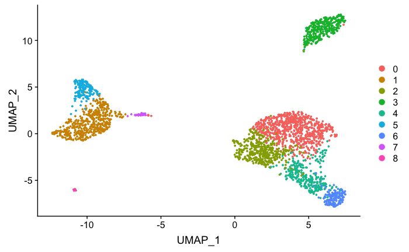

```r
# note that you can set `label = TRUE` or use the LabelClusters function to help label
# individual clusters
# if umap is giving you trouble, replace "umap" with "tsne" for this workshop
DimPlot(pbmc, reduction = "umap")
```

```r
?DimPlot
```

Some options to be aware of: pt.size = 1 #changes dots reduction = “tsne” #can be used to plot a `tsne` (but you have to compute it!) or `pca` instead of `umap` group.by = “orig.ident” #can be used if you have several combined datasets of different ages/genotypes, etc cells.highlight = [vector] #can be used to highlight cells of interest by passing a vector of cell names

### Saving

You can save the object at this point so that it can easily be loaded back in without having to rerun the computationally intensive steps performed above, or so that it can be easily shared with collaborators.

```r
saveRDS(pbmc, file = "./output/pbmc_tutorial.rds")
#pbmc = loadRDS("./output/pbmc_tutorial.rds")
```

### Finding differentially expressed features (cluster biomarkers):

Seurat can help you find markers that define clusters via differential expression. By default, it identifes positive and negative markers of a single cluster (specified in `ident.1`), compared to all other cells. `FindAllMarkers` automates this process for all clusters, but you can also test groups of clusters vs. each other, or against all cells.

The `min.pct` argument requires a feature to be detected at a minimum percentage in either of the two groups of cells, and the thresh.test argument requires a feature to be differentially expressed (on average) by some amount between the two groups. You can set both of these to 0, but with a dramatic increase in time - since this will test a large number of features that are unlikely to be highly discriminatory. As another option to speed up these computations, `max.cells.per.ident` can be set. This will downsample each identity class to have no more cells than whatever this is set to. While there is generally going to be a loss in power, the speed increases can be significiant and the most highly differentially expressed features will likely still rise to the top.

```r
# find all markers of cluster 1
cluster1.markers <- FindMarkers(pbmc, ident.1 = 1, min.pct = 0.25)
```

[output not shown]

[output cut: 45 more lines]

[output not shown]

```r
head(cluster1.markers, n = 5)
```

|  | p_val | avg_logFC | pct.1 | pct.2 | p_val_adj |
| --- | --- | --- | --- | --- | --- |
| S100A9 | 0.000000e+00 | 3.860873 | 0.996 | 0.215 | 0.000000e+00 |
| S100A8 | 0.000000e+00 | 3.796640 | 0.975 | 0.121 | 0.000000e+00 |
| LGALS2 | 0.000000e+00 | 2.634294 | 0.908 | 0.059 | 0.000000e+00 |
| FCN1 | 0.000000e+00 | 2.352693 | 0.952 | 0.151 | 0.000000e+00 |
| CD14 | 2.856582e-294 | 1.951644 | 0.667 | 0.028 | 3.917516e-290 |

```r
# find all markers distinguishing cluster 5 from clusters 0 and 3
cluster5.markers <- FindMarkers(pbmc, ident.1 = 5, ident.2 = c(0, 3), min.pct = 0.25)
```

[output not shown]

[output cut: 42 more lines]

[output not shown]

```r
head(cluster5.markers, n = 5)
```

|  | p_val | avg_logFC | pct.1 | pct.2 | p_val_adj |
| --- | --- | --- | --- | --- | --- |
| FCGR3A | 2.821516e-210 | 2.953991 | 0.975 | 0.040 | 3.869427e-206 |
| CFD | 9.299939e-201 | 2.372472 | 0.938 | 0.036 | 1.275394e-196 |
| IFITM3 | 1.190905e-200 | 2.686409 | 0.975 | 0.049 | 1.633207e-196 |
| CD68 | 5.770643e-197 | 2.091911 | 0.926 | 0.035 | 7.913860e-193 |
| RP11-290F20.3 | 2.208504e-193 | 1.888258 | 0.840 | 0.016 | 3.028743e-189 |

```r
# find markers for every cluster compared to all remaining cells, report only the positive ones
pbmc.markers <- FindAllMarkers(pbmc, only.pos = TRUE, min.pct = 0.25, logfc.threshold = 0.25)
```

[output not shown]

[output cut: 13 more lines]

[output not shown]

[output not shown]

[output cut: 35 more lines]

[output not shown]

[output not shown]

[output cut: 43 more lines]

[output not shown]

[output not shown]

[output cut: 9 more lines]

[output not shown]

[output not shown]

[output cut: 12 more lines]

[output not shown]

[output not shown]

[output cut: 46 more lines]

[output not shown]

[output not shown]

[output cut: 38 more lines]

[output not shown]

[output not shown]

[output cut: 32 more lines]

[output not shown]

[output not shown]

[output cut: 38 more lines]

[output not shown]

```r
pbmc.markers %>% group_by(cluster) %>% top_n(n = 2, wt = avg_logFC)
```

| p_val | avg_logFC | pct.1 | pct.2 | p_val_adj | cluster | gene |
| --- | --- | --- | --- | --- | --- | --- |
| 7.889955e-121 | 0.7573258 | 0.911 | 0.585 | 1.082028e-116 | 0 | LDHB |
| 1.200589e-82 | 0.9159384 | 0.429 | 0.107 | 1.646488e-78 | 0 | CCR7 |
| 0.000000e+00 | 3.8608733 | 0.996 | 0.215 | 0.000000e+00 | 1 | S100A9 |
| 0.000000e+00 | 3.7966403 | 0.975 | 0.121 | 0.000000e+00 | 1 | S100A8 |
| 4.524861e-78 | 0.8783693 | 0.981 | 0.651 | 6.205395e-74 | 2 | LTB |
| 4.988628e-59 | 0.8041229 | 0.749 | 0.337 | 6.841404e-55 | 2 | IL7R |
| 0.000000e+00 | 2.9908741 | 0.939 | 0.042 | 0.000000e+00 | 3 | CD79A |
| 1.055671e-269 | 2.4860187 | 0.623 | 0.022 | 1.447748e-265 | 3 | TCL1A |
| 1.636327e-213 | 2.1945234 | 0.987 | 0.230 | 2.244059e-209 | 4 | CCL5 |
| 1.929969e-176 | 2.0956796 | 0.584 | 0.052 | 2.646759e-172 | 4 | GZMK |

[output cut: 8 more lines]

```r
pbmc.markers.0 = pbmc.markers[pbmc.markers$cluster == 0,] #example of subsetting the FindAllMarkers result for Cluster 0
```

Seurat has several tests for differential expression which can be set with the test.use parameter (see the DE vignette for details). For example, the ROC test returns the ‘classification power’ for any individual marker (ranging from 0 - random, to 1 - perfect).

```r
cluster1.markers <- FindMarkers(pbmc, ident.1 = 0, logfc.threshold = 0.25, test.use = "roc", only.pos = TRUE)
```

[output not shown]

[output cut: 35 more lines]

[output not shown]

Seurat includes several tools for visualizing marker expression. `VlnPlot` (shows expression probability distributions across clusters), and `FeaturePlot` (visualizes feature expression on a tSNE or PCA plot) are our most commonly used visualizations. We also suggest exploring `RidgePlot`, `CellScatter`, and `DotPlot` as additional methods to view your dataset.

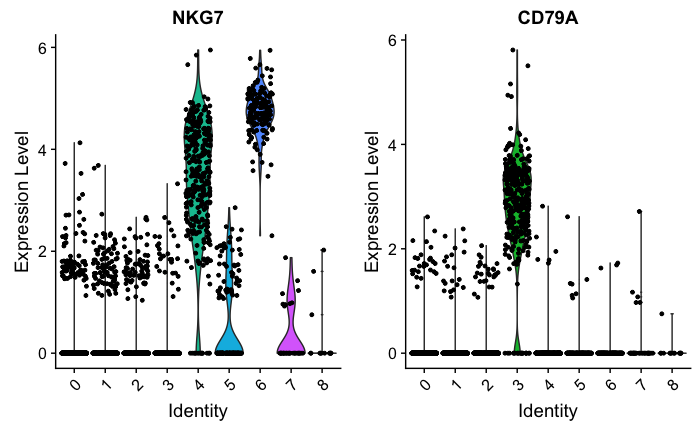

```r
VlnPlot(pbmc, features = c("NKG7", "CD79A"))
```

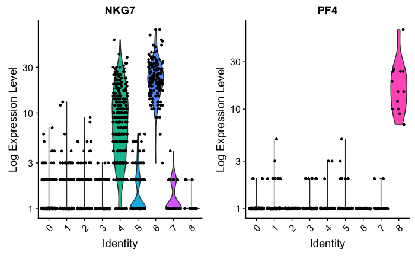

```r
# you can plot raw counts as well
VlnPlot(pbmc, features = c("NKG7", "PF4"), slot = "counts", log = TRUE)
```

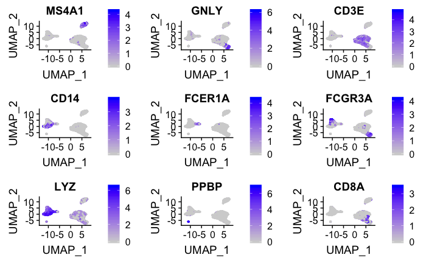

```r
FeaturePlot(pbmc, features = c("MS4A1", "GNLY", "CD3E", "CD14", "FCER1A", "FCGR3A", "LYZ", "PPBP",
    "CD8A"))
```

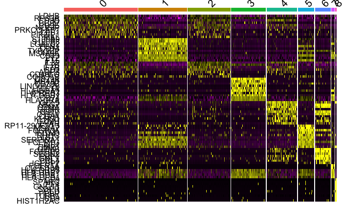

```r
top10 <- pbmc.markers %>% group_by(cluster) %>% top_n(n = 10, wt = avg_logFC)
DoHeatmap(pbmc, features = top10$gene) + NoLegend()
```